# Risk Factor Analysis

## Outcome Variable

**Outcome Variable:** ever_wasted

## Predictor Variables

**Intervention Variable:** perdiar24

**Adjustment Set:**

- arm
- sex
- hfoodsec
- W_birthwt
- W_birthlen
- W_nrooms
- month
- brthmon
- impfloor
- impsan
- safeh20
- delta_hfoodsec
- delta_W_birthwt
- delta_W_birthlen
- delta_W_nrooms
- delta_month
- delta_brthmon
- delta_impfloor
- delta_impsan
- delta_safeh20

## Stratifying Variables

The analysis was stratified on these variable(s):

- agecat
- studyid
- country

## Data Summary

| agecat | studyid | country | perdiar24 | ever_wasted | n_cell | n |
| --- | --- | --- | --- | --- | --- | --- |
| 0-24 months (no birth wast) | ki0047075b-MAL-ED | BANGLADESH | 0% | 0 | 17 | 263 |
| 0-24 months (no birth wast) | ki0047075b-MAL-ED | BANGLADESH | 0% | 1 | 3 | 263 |
| 0-24 months (no birth wast) | ki0047075b-MAL-ED | BANGLADESH | (0%, 5%] | 0 | 112 | 263 |
| 0-24 months (no birth wast) | ki0047075b-MAL-ED | BANGLADESH | (0%, 5%] | 1 | 36 | 263 |
| 0-24 months (no birth wast) | ki0047075b-MAL-ED | BANGLADESH | >5% | 0 | 76 | 263 |
| 0-24 months (no birth wast) | ki0047075b-MAL-ED | BANGLADESH | >5% | 1 | 19 | 263 |
| 0-24 months (no birth wast) | ki0047075b-MAL-ED | BRAZIL | 0% | 0 | 124 | 232 |
| 0-24 months (no birth wast) | ki0047075b-MAL-ED | BRAZIL | 0% | 1 | 6 | 232 |
| 0-24 months (no birth wast) | ki0047075b-MAL-ED | BRAZIL | (0%, 5%] | 0 | 95 | 232 |
| 0-24 months (no birth wast) | ki0047075b-MAL-ED | BRAZIL | (0%, 5%] | 1 | 5 | 232 |
| 0-24 months (no birth wast) | ki0047075b-MAL-ED | BRAZIL | >5% | 0 | 1 | 232 |
| 0-24 months (no birth wast) | ki0047075b-MAL-ED | BRAZIL | >5% | 1 | 1 | 232 |
| 0-24 months (no birth wast) | ki0047075b-MAL-ED | INDIA | 0% | 0 | 12 | 246 |
| 0-24 months (no birth wast) | ki0047075b-MAL-ED | INDIA | 0% | 1 | 1 | 246 |
| 0-24 months (no birth wast) | ki0047075b-MAL-ED | INDIA | (0%, 5%] | 0 | 118 | 246 |
| 0-24 months (no birth wast) | ki0047075b-MAL-ED | INDIA | (0%, 5%] | 1 | 73 | 246 |
| 0-24 months (no birth wast) | ki0047075b-MAL-ED | INDIA | >5% | 0 | 27 | 246 |
| 0-24 months (no birth wast) | ki0047075b-MAL-ED | INDIA | >5% | 1 | 15 | 246 |
| 0-24 months (no birth wast) | ki0047075b-MAL-ED | NEPAL | 0% | 0 | 16 | 239 |
| 0-24 months (no birth wast) | ki0047075b-MAL-ED | NEPAL | 0% | 1 | 1 | 239 |
| 0-24 months (no birth wast) | ki0047075b-MAL-ED | NEPAL | (0%, 5%] | 0 | 113 | 239 |
| 0-24 months (no birth wast) | ki0047075b-MAL-ED | NEPAL | (0%, 5%] | 1 | 30 | 239 |
| 0-24 months (no birth wast) | ki0047075b-MAL-ED | NEPAL | >5% | 0 | 65 | 239 |
| 0-24 months (no birth wast) | ki0047075b-MAL-ED | NEPAL | >5% | 1 | 14 | 239 |
| 0-24 months (no birth wast) | ki0047075b-MAL-ED | PERU | 0% | 0 | 28 | 302 |
| 0-24 months (no birth wast) | ki0047075b-MAL-ED | PERU | 0% | 1 | 0 | 302 |
| 0-24 months (no birth wast) | ki0047075b-MAL-ED | PERU | (0%, 5%] | 0 | 106 | 302 |
| 0-24 months (no birth wast) | ki0047075b-MAL-ED | PERU | (0%, 5%] | 1 | 7 | 302 |
| 0-24 months (no birth wast) | ki0047075b-MAL-ED | PERU | >5% | 0 | 148 | 302 |
| 0-24 months (no birth wast) | ki0047075b-MAL-ED | PERU | >5% | 1 | 13 | 302 |

[output cut: 342 more lines]

The following strata were considered:

- agecat: 0-24 months (no birth wast), studyid: ki0047075b-MAL-ED, country: BANGLADESH
- agecat: 0-24 months (no birth wast), studyid: ki0047075b-MAL-ED, country: BRAZIL
- agecat: 0-24 months (no birth wast), studyid: ki0047075b-MAL-ED, country: INDIA
- agecat: 0-24 months (no birth wast), studyid: ki0047075b-MAL-ED, country: NEPAL
- agecat: 0-24 months (no birth wast), studyid: ki0047075b-MAL-ED, country: PERU
- agecat: 0-24 months (no birth wast), studyid: ki0047075b-MAL-ED, country: SOUTH AFRICA
- agecat: 0-24 months (no birth wast), studyid: ki0047075b-MAL-ED, country: TANZANIA, UNITED REPUBLIC OF
- agecat: 0-24 months (no birth wast), studyid: ki1000109-EE, country: PAKISTAN
- agecat: 0-24 months (no birth wast), studyid: ki1000109-ResPak, country: PAKISTAN
- agecat: 0-24 months (no birth wast), studyid: ki1000304b-SAS-FoodSuppl, country: INDIA
- agecat: 0-24 months (no birth wast), studyid: ki1017093-NIH-Birth, country: BANGLADESH
- agecat: 0-24 months (no birth wast), studyid: ki1017093b-PROVIDE, country: BANGLADESH
- agecat: 0-24 months (no birth wast), studyid: ki1017093c-NIH-Crypto, country: BANGLADESH
- agecat: 0-24 months (no birth wast), studyid: ki1112895-Guatemala BSC, country: GUATEMALA
- agecat: 0-24 months (no birth wast), studyid: ki1112895-iLiNS-Zinc, country: BURKINA FASO
- agecat: 0-24 months (no birth wast), studyid: ki1114097-CMIN, country: BANGLADESH
- agecat: 0-24 months (no birth wast), studyid: ki1114097-CMIN, country: BRAZIL
- agecat: 0-24 months (no birth wast), studyid: ki1114097-CMIN, country: GUINEA-BISSAU
- agecat: 0-24 months (no birth wast), studyid: ki1114097-CMIN, country: PERU
- agecat: 0-24 months (no birth wast), studyid: ki1114097-CONTENT, country: PERU
- agecat: 0-24 months (no birth wast), studyid: kiGH5241-JiVitA-4, country: BANGLADESH
- agecat: 0-6 months (no birth wast), studyid: ki0047075b-MAL-ED, country: BANGLADESH
- agecat: 0-6 months (no birth wast), studyid: ki0047075b-MAL-ED, country: BRAZIL
- agecat: 0-6 months (no birth wast), studyid: ki0047075b-MAL-ED, country: INDIA
- agecat: 0-6 months (no birth wast), studyid: ki0047075b-MAL-ED, country: NEPAL
- agecat: 0-6 months (no birth wast), studyid: ki0047075b-MAL-ED, country: PERU
- agecat: 0-6 months (no birth wast), studyid: ki0047075b-MAL-ED, country: SOUTH AFRICA
- agecat: 0-6 months (no birth wast), studyid: ki0047075b-MAL-ED, country: TANZANIA, UNITED REPUBLIC OF
- agecat: 0-6 months (no birth wast), studyid: ki1000109-EE, country: PAKISTAN
- agecat: 0-6 months (no birth wast), studyid: ki1000109-ResPak, country: PAKISTAN
- agecat: 0-6 months (no birth wast), studyid: ki1000304b-SAS-FoodSuppl, country: INDIA
- agecat: 0-6 months (no birth wast), studyid: ki1017093-NIH-Birth, country: BANGLADESH
- agecat: 0-6 months (no birth wast), studyid: ki1017093b-PROVIDE, country: BANGLADESH
- agecat: 0-6 months (no birth wast), studyid: ki1017093c-NIH-Crypto, country: BANGLADESH
- agecat: 0-6 months (no birth wast), studyid: ki1112895-Guatemala BSC, country: GUATEMALA
- agecat: 0-6 months (no birth wast), studyid: ki1114097-CMIN, country: BANGLADESH
- agecat: 0-6 months (no birth wast), studyid: ki1114097-CMIN, country: BRAZIL
- agecat: 0-6 months (no birth wast), studyid: ki1114097-CMIN, country: GUINEA-BISSAU
- agecat: 0-6 months (no birth wast), studyid: ki1114097-CMIN, country: PERU
- agecat: 0-6 months (no birth wast), studyid: ki1114097-CONTENT, country: PERU
- agecat: 0-6 months (no birth wast), studyid: kiGH5241-JiVitA-4, country: BANGLADESH
- agecat: 6-24 months, studyid: ki0047075b-MAL-ED, country: BANGLADESH
- agecat: 6-24 months, studyid: ki0047075b-MAL-ED, country: BRAZIL
- agecat: 6-24 months, studyid: ki0047075b-MAL-ED, country: INDIA
- agecat: 6-24 months, studyid: ki0047075b-MAL-ED, country: NEPAL
- agecat: 6-24 months, studyid: ki0047075b-MAL-ED, country: PERU
- agecat: 6-24 months, studyid: ki0047075b-MAL-ED, country: SOUTH AFRICA
- agecat: 6-24 months, studyid: ki0047075b-MAL-ED, country: TANZANIA, UNITED REPUBLIC OF
- agecat: 6-24 months, studyid: ki1000109-EE, country: PAKISTAN
- agecat: 6-24 months, studyid: ki1000109-ResPak, country: PAKISTAN
- agecat: 6-24 months, studyid: ki1000304b-SAS-FoodSuppl, country: INDIA
- agecat: 6-24 months, studyid: ki1017093-NIH-Birth, country: BANGLADESH
- agecat: 6-24 months, studyid: ki1017093b-PROVIDE, country: BANGLADESH
- agecat: 6-24 months, studyid: ki1017093c-NIH-Crypto, country: BANGLADESH
- agecat: 6-24 months, studyid: ki1112895-Guatemala BSC, country: GUATEMALA
- agecat: 6-24 months, studyid: ki1112895-iLiNS-Zinc, country: BURKINA FASO
- agecat: 6-24 months, studyid: ki1114097-CMIN, country: BANGLADESH
- agecat: 6-24 months, studyid: ki1114097-CMIN, country: BRAZIL
- agecat: 6-24 months, studyid: ki1114097-CMIN, country: GUINEA-BISSAU
- agecat: 6-24 months, studyid: ki1114097-CMIN, country: PERU
- agecat: 6-24 months, studyid: ki1114097-CONTENT, country: PERU
- agecat: 6-24 months, studyid: kiGH5241-JiVitA-4, country: BANGLADESH

### Dropped Strata

Some strata were dropped due to rare outcomes:

- agecat: 0-24 months (no birth wast), studyid: ki0047075b-MAL-ED, country: BANGLADESH
- agecat: 0-24 months (no birth wast), studyid: ki0047075b-MAL-ED, country: BRAZIL
- agecat: 0-24 months (no birth wast), studyid: ki0047075b-MAL-ED, country: INDIA
- agecat: 0-24 months (no birth wast), studyid: ki0047075b-MAL-ED, country: NEPAL
- agecat: 0-24 months (no birth wast), studyid: ki0047075b-MAL-ED, country: PERU
- agecat: 0-24 months (no birth wast), studyid: ki0047075b-MAL-ED, country: SOUTH AFRICA
- agecat: 0-24 months (no birth wast), studyid: ki0047075b-MAL-ED, country: TANZANIA, UNITED REPUBLIC OF
- agecat: 0-24 months (no birth wast), studyid: ki1017093-NIH-Birth, country: BANGLADESH
- agecat: 0-24 months (no birth wast), studyid: ki1017093b-PROVIDE, country: BANGLADESH
- agecat: 0-24 months (no birth wast), studyid: ki1112895-Guatemala BSC, country: GUATEMALA
- agecat: 0-24 months (no birth wast), studyid: ki1114097-CMIN, country: BANGLADESH
- agecat: 0-24 months (no birth wast), studyid: ki1114097-CMIN, country: BRAZIL
- agecat: 0-24 months (no birth wast), studyid: ki1114097-CMIN, country: PERU
- agecat: 0-24 months (no birth wast), studyid: ki1114097-CONTENT, country: PERU
- agecat: 0-6 months (no birth wast), studyid: ki0047075b-MAL-ED, country: BANGLADESH
- agecat: 0-6 months (no birth wast), studyid: ki0047075b-MAL-ED, country: BRAZIL
- agecat: 0-6 months (no birth wast), studyid: ki0047075b-MAL-ED, country: INDIA
- agecat: 0-6 months (no birth wast), studyid: ki0047075b-MAL-ED, country: NEPAL
- agecat: 0-6 months (no birth wast), studyid: ki0047075b-MAL-ED, country: PERU
- agecat: 0-6 months (no birth wast), studyid: ki0047075b-MAL-ED, country: SOUTH AFRICA
- agecat: 0-6 months (no birth wast), studyid: ki0047075b-MAL-ED, country: TANZANIA, UNITED REPUBLIC OF
- agecat: 0-6 months (no birth wast), studyid: ki1000109-EE, country: PAKISTAN
- agecat: 0-6 months (no birth wast), studyid: ki1000304b-SAS-FoodSuppl, country: INDIA
- agecat: 0-6 months (no birth wast), studyid: ki1017093-NIH-Birth, country: BANGLADESH
- agecat: 0-6 months (no birth wast), studyid: ki1017093b-PROVIDE, country: BANGLADESH
- agecat: 0-6 months (no birth wast), studyid: ki1017093c-NIH-Crypto, country: BANGLADESH
- agecat: 0-6 months (no birth wast), studyid: ki1112895-Guatemala BSC, country: GUATEMALA
- agecat: 0-6 months (no birth wast), studyid: ki1114097-CMIN, country: BANGLADESH
- agecat: 0-6 months (no birth wast), studyid: ki1114097-CMIN, country: BRAZIL
- agecat: 0-6 months (no birth wast), studyid: ki1114097-CMIN, country: GUINEA-BISSAU
- agecat: 0-6 months (no birth wast), studyid: ki1114097-CMIN, country: PERU
- agecat: 0-6 months (no birth wast), studyid: ki1114097-CONTENT, country: PERU
- agecat: 6-24 months, studyid: ki0047075b-MAL-ED, country: BANGLADESH
- agecat: 6-24 months, studyid: ki0047075b-MAL-ED, country: BRAZIL
- agecat: 6-24 months, studyid: ki0047075b-MAL-ED, country: INDIA
- agecat: 6-24 months, studyid: ki0047075b-MAL-ED, country: NEPAL
- agecat: 6-24 months, studyid: ki0047075b-MAL-ED, country: PERU
- agecat: 6-24 months, studyid: ki0047075b-MAL-ED, country: SOUTH AFRICA
- agecat: 6-24 months, studyid: ki0047075b-MAL-ED, country: TANZANIA, UNITED REPUBLIC OF
- agecat: 6-24 months, studyid: ki1000109-ResPak, country: PAKISTAN
- agecat: 6-24 months, studyid: ki1017093-NIH-Birth, country: BANGLADESH
- agecat: 6-24 months, studyid: ki1017093b-PROVIDE, country: BANGLADESH
- agecat: 6-24 months, studyid: ki1112895-Guatemala BSC, country: GUATEMALA
- agecat: 6-24 months, studyid: ki1114097-CMIN, country: BANGLADESH
- agecat: 6-24 months, studyid: ki1114097-CMIN, country: BRAZIL
- agecat: 6-24 months, studyid: ki1114097-CMIN, country: PERU
- agecat: 6-24 months, studyid: ki1114097-CONTENT, country: PERU

## Methods Detail

We’re interested in the causal parameters $E[Y_a]$ for all values of $a \in \mathcal{A}$. These parameters represent the mean outcome if, possibly contrary to fact, we intervened to set all units to have $A=a$. Under the randomization and positivity assumptions, these are identified by the statistical parameters $\psi_a=E_W[E_{Y|A,W}(Y|A=a,W)]$. In addition, we’re interested in the mean of $Y$, $E[Y]$ under no intervention (the observed mean). We will estimate these parameters by using SuperLearner to fit the relevant likelihood factors – $E_{Y|A,W}(Y|A=a,W)$ and $p(A=a|W)$, and then updating our likelihood fit using a joint TMLE.

For unadjusted analyses ($W=\{\}$), initial likelihoods were estimated using Lrnr_glm to estimate the simple $E(Y|A)$ and Lrnr_mean to estimate $p(A)$. For adjusted analyses, a small library containing Lrnr_glmnet, Lrnr_xgboost, and Lrnr_mean was used.

Having estimated these parameters, we will then use the delta method to estimate relative risks and attributable risks relative to a prespecified baseline level of $A$.

# Results Detail

## Results Plots

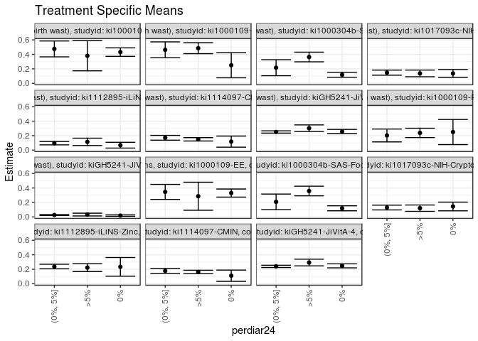

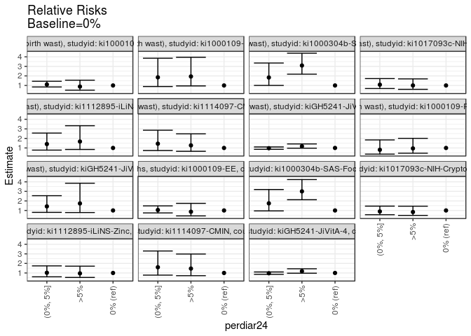

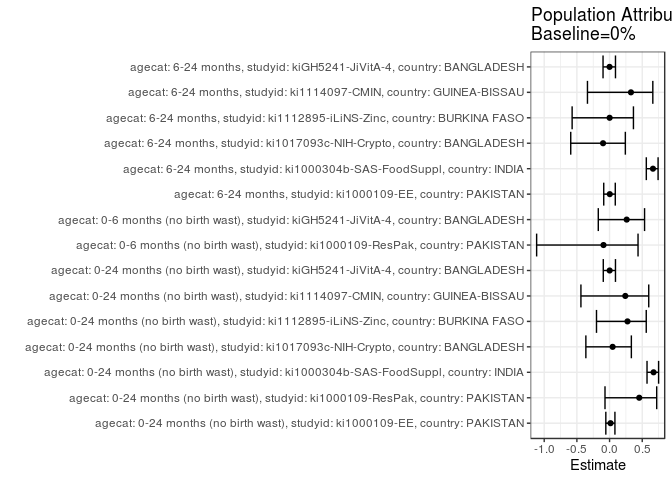

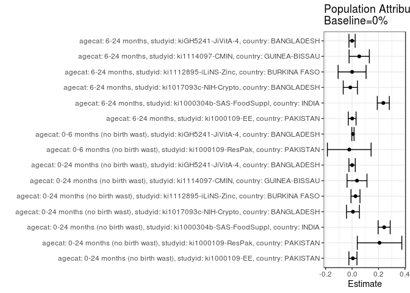

## Results Table

### Parameter: TSM

| agecat | studyid | country | intervention_level | baseline_level | estimate | ci_lower | ci_upper |
| --- | --- | --- | --- | --- | --- | --- | --- |
| 0-24 months (no birth wast) | ki1000109-EE | PAKISTAN | 0% | NA | 0.4311594 | 0.3726556 | 0.4896633 |
| 0-24 months (no birth wast) | ki1000109-EE | PAKISTAN | (0%, 5%] | NA | 0.4750000 | 0.3654263 | 0.5845737 |
| 0-24 months (no birth wast) | ki1000109-EE | PAKISTAN | >5% | NA | 0.3809524 | 0.1729767 | 0.5889281 |
| 0-24 months (no birth wast) | ki1000109-ResPak | PAKISTAN | 0% | NA | 0.2500000 | 0.0764439 | 0.4235561 |
| 0-24 months (no birth wast) | ki1000109-ResPak | PAKISTAN | (0%, 5%] | NA | 0.4625000 | 0.3530426 | 0.5719574 |
| 0-24 months (no birth wast) | ki1000109-ResPak | PAKISTAN | >5% | NA | 0.4852071 | 0.4097185 | 0.5606957 |
| 0-24 months (no birth wast) | ki1000304b-SAS-FoodSuppl | INDIA | 0% | NA | 0.1175807 | 0.0830015 | 0.1521600 |
| 0-24 months (no birth wast) | ki1000304b-SAS-FoodSuppl | INDIA | (0%, 5%] | NA | 0.2157116 | 0.1053053 | 0.3261178 |
| 0-24 months (no birth wast) | ki1000304b-SAS-FoodSuppl | INDIA | >5% | NA | 0.3633426 | 0.2966164 | 0.4300688 |
| 0-24 months (no birth wast) | ki1017093c-NIH-Crypto | BANGLADESH | 0% | NA | 0.1365059 | 0.0819323 | 0.1910796 |
| 0-24 months (no birth wast) | ki1017093c-NIH-Crypto | BANGLADESH | (0%, 5%] | NA | 0.1476974 | 0.1127439 | 0.1826509 |
| 0-24 months (no birth wast) | ki1017093c-NIH-Crypto | BANGLADESH | >5% | NA | 0.1367850 | 0.0904101 | 0.1831600 |
| 0-24 months (no birth wast) | ki1112895-iLiNS-Zinc | BURKINA FASO | 0% | NA | 0.0682275 | 0.0283105 | 0.1081446 |
| 0-24 months (no birth wast) | ki1112895-iLiNS-Zinc | BURKINA FASO | (0%, 5%] | NA | 0.0960894 | 0.0729563 | 0.1192226 |
| 0-24 months (no birth wast) | ki1112895-iLiNS-Zinc | BURKINA FASO | >5% | NA | 0.1141851 | 0.0633263 | 0.1650439 |
| 0-24 months (no birth wast) | ki1114097-CMIN | GUINEA-BISSAU | 0% | NA | 0.1176471 | 0.0410428 | 0.1942513 |
| 0-24 months (no birth wast) | ki1114097-CMIN | GUINEA-BISSAU | (0%, 5%] | NA | 0.1703854 | 0.1371863 | 0.2035845 |
| 0-24 months (no birth wast) | ki1114097-CMIN | GUINEA-BISSAU | >5% | NA | 0.1494505 | 0.1262780 | 0.1726231 |
| 0-24 months (no birth wast) | kiGH5241-JiVitA-4 | BANGLADESH | 0% | NA | 0.2573970 | 0.2288305 | 0.2859635 |
| 0-24 months (no birth wast) | kiGH5241-JiVitA-4 | BANGLADESH | (0%, 5%] | NA | 0.2505007 | 0.2347457 | 0.2662556 |
| 0-24 months (no birth wast) | kiGH5241-JiVitA-4 | BANGLADESH | >5% | NA | 0.3028630 | 0.2575423 | 0.3481838 |
| 0-6 months (no birth wast) | ki1000109-ResPak | PAKISTAN | 0% | NA | 0.2500000 | 0.0764415 | 0.4235585 |
| 0-6 months (no birth wast) | ki1000109-ResPak | PAKISTAN | (0%, 5%] | NA | 0.2025316 | 0.1137465 | 0.2913168 |
| 0-6 months (no birth wast) | ki1000109-ResPak | PAKISTAN | >5% | NA | 0.2380952 | 0.1735711 | 0.3026193 |
| 0-6 months (no birth wast) | kiGH5241-JiVitA-4 | BANGLADESH | 0% | NA | 0.0189068 | 0.0088281 | 0.0289854 |
| 0-6 months (no birth wast) | kiGH5241-JiVitA-4 | BANGLADESH | (0%, 5%] | NA | 0.0269874 | 0.0213301 | 0.0326447 |
| 0-6 months (no birth wast) | kiGH5241-JiVitA-4 | BANGLADESH | >5% | NA | 0.0327830 | 0.0136127 | 0.0519534 |
| 6-24 months | ki1000109-EE | PAKISTAN | 0% | NA | 0.3296703 | 0.2738322 | 0.3855084 |
| 6-24 months | ki1000109-EE | PAKISTAN | (0%, 5%] | NA | 0.3456790 | 0.2419698 | 0.4493882 |
| 6-24 months | ki1000109-EE | PAKISTAN | >5% | NA | 0.2857143 | 0.0922413 | 0.4791872 |
| 6-24 months | ki1000304b-SAS-FoodSuppl | INDIA | 0% | NA | 0.1194187 | 0.0847853 | 0.1540521 |
| 6-24 months | ki1000304b-SAS-FoodSuppl | INDIA | (0%, 5%] | NA | 0.2083921 | 0.1006506 | 0.3161336 |
| 6-24 months | ki1000304b-SAS-FoodSuppl | INDIA | >5% | NA | 0.3582269 | 0.2918228 | 0.4246310 |
| 6-24 months | ki1017093c-NIH-Crypto | BANGLADESH | 0% | NA | 0.1446153 | 0.0845797 | 0.2046509 |
| 6-24 months | ki1017093c-NIH-Crypto | BANGLADESH | (0%, 5%] | NA | 0.1297382 | 0.0967861 | 0.1626902 |
| 6-24 months | ki1017093c-NIH-Crypto | BANGLADESH | >5% | NA | 0.1209819 | 0.0770650 | 0.1648988 |
| 6-24 months | ki1112895-iLiNS-Zinc | BURKINA FASO | 0% | NA | 0.2333639 | 0.1048121 | 0.3619157 |
| 6-24 months | ki1112895-iLiNS-Zinc | BURKINA FASO | (0%, 5%] | NA | 0.2379564 | 0.2065780 | 0.2693348 |
| 6-24 months | ki1112895-iLiNS-Zinc | BURKINA FASO | >5% | NA | 0.2228568 | 0.1687674 | 0.2769461 |
| 6-24 months | ki1114097-CMIN | GUINEA-BISSAU | 0% | NA | 0.1111111 | 0.0334811 | 0.1887411 |
| 6-24 months | ki1114097-CMIN | GUINEA-BISSAU | (0%, 5%] | NA | 0.1776860 | 0.1436200 | 0.2117519 |
| 6-24 months | ki1114097-CMIN | GUINEA-BISSAU | >5% | NA | 0.1622517 | 0.1382365 | 0.1862668 |
| 6-24 months | kiGH5241-JiVitA-4 | BANGLADESH | 0% | NA | 0.2473605 | 0.2195591 | 0.2751618 |
| 6-24 months | kiGH5241-JiVitA-4 | BANGLADESH | (0%, 5%] | NA | 0.2400058 | 0.2243437 | 0.2556679 |
| 6-24 months | kiGH5241-JiVitA-4 | BANGLADESH | >5% | NA | 0.2928954 | 0.2468012 | 0.3389896 |

### Parameter: E(Y)

| agecat | studyid | country | intervention_level | baseline_level | estimate | ci_lower | ci_upper |
| --- | --- | --- | --- | --- | --- | --- | --- |
| 0-24 months (no birth wast) | ki1000109-EE | PAKISTAN | NA | NA | 0.4376658 | 0.3875213 | 0.4878102 |
| 0-24 months (no birth wast) | ki1000109-ResPak | PAKISTAN | NA | NA | 0.4578755 | 0.3986666 | 0.5170843 |
| 0-24 months (no birth wast) | ki1000304b-SAS-FoodSuppl | INDIA | NA | NA | 0.3602015 | 0.3129196 | 0.4074834 |
| 0-24 months (no birth wast) | ki1017093c-NIH-Crypto | BANGLADESH | NA | NA | 0.1432361 | 0.1182149 | 0.1682572 |
| 0-24 months (no birth wast) | ki1112895-iLiNS-Zinc | BURKINA FASO | NA | NA | 0.0940426 | 0.0721067 | 0.1159784 |
| 0-24 months (no birth wast) | ki1114097-CMIN | GUINEA-BISSAU | NA | NA | 0.1549966 | 0.1364963 | 0.1734969 |
| 0-24 months (no birth wast) | kiGH5241-JiVitA-4 | BANGLADESH | NA | NA | 0.2577835 | 0.2441424 | 0.2714247 |
| 0-6 months (no birth wast) | ki1000109-ResPak | PAKISTAN | NA | NA | 0.2287823 | 0.1786790 | 0.2788855 |
| 0-6 months (no birth wast) | kiGH5241-JiVitA-4 | BANGLADESH | NA | NA | 0.0256203 | 0.0209093 | 0.0303314 |
| 6-24 months | ki1000109-EE | PAKISTAN | NA | NA | 0.3306667 | 0.2829875 | 0.3783458 |
| 6-24 months | ki1000304b-SAS-FoodSuppl | INDIA | NA | NA | 0.3557214 | 0.3088651 | 0.4025777 |
| 6-24 months | ki1017093c-NIH-Crypto | BANGLADESH | NA | NA | 0.1315069 | 0.1069744 | 0.1560393 |
| 6-24 months | ki1112895-iLiNS-Zinc | BURKINA FASO | NA | NA | 0.2335915 | 0.1982492 | 0.2689339 |
| 6-24 months | ki1114097-CMIN | GUINEA-BISSAU | NA | NA | 0.1651755 | 0.1460754 | 0.1842756 |
| 6-24 months | kiGH5241-JiVitA-4 | BANGLADESH | NA | NA | 0.2473297 | 0.2337864 | 0.2608729 |

### Parameter: RR

| agecat | studyid | country | intervention_level | baseline_level | estimate | ci_lower | ci_upper |
| --- | --- | --- | --- | --- | --- | --- | --- |
| 0-24 months (no birth wast) | ki1000109-EE | PAKISTAN | 0% | 0% | 1.0000000 | 1.0000000 | 1.000000 |
| 0-24 months (no birth wast) | ki1000109-EE | PAKISTAN | (0%, 5%] | 0% | 1.1016807 | 0.8429963 | 1.439746 |
| 0-24 months (no birth wast) | ki1000109-EE | PAKISTAN | >5% | 0% | 0.8835534 | 0.5034104 | 1.550756 |
| 0-24 months (no birth wast) | ki1000109-ResPak | PAKISTAN | 0% | 0% | 1.0000000 | 1.0000000 | 1.000000 |
| 0-24 months (no birth wast) | ki1000109-ResPak | PAKISTAN | (0%, 5%] | 0% | 1.8500000 | 0.8884557 | 3.852190 |
| 0-24 months (no birth wast) | ki1000109-ResPak | PAKISTAN | >5% | 0% | 1.9408284 | 0.9528199 | 3.953333 |
| 0-24 months (no birth wast) | ki1000304b-SAS-FoodSuppl | INDIA | 0% | 0% | 1.0000000 | 1.0000000 | 1.000000 |
| 0-24 months (no birth wast) | ki1000304b-SAS-FoodSuppl | INDIA | (0%, 5%] | 0% | 1.8345826 | 1.0047589 | 3.349752 |
| 0-24 months (no birth wast) | ki1000304b-SAS-FoodSuppl | INDIA | >5% | 0% | 3.0901540 | 2.1824380 | 4.375406 |
| 0-24 months (no birth wast) | ki1017093c-NIH-Crypto | BANGLADESH | 0% | 0% | 1.0000000 | 1.0000000 | 1.000000 |
| 0-24 months (no birth wast) | ki1017093c-NIH-Crypto | BANGLADESH | (0%, 5%] | 0% | 1.0819852 | 0.6814043 | 1.718058 |
| 0-24 months (no birth wast) | ki1017093c-NIH-Crypto | BANGLADESH | >5% | 0% | 1.0020444 | 0.5950635 | 1.687371 |
| 0-24 months (no birth wast) | ki1112895-iLiNS-Zinc | BURKINA FASO | 0% | 0% | 1.0000000 | 1.0000000 | 1.000000 |
| 0-24 months (no birth wast) | ki1112895-iLiNS-Zinc | BURKINA FASO | (0%, 5%] | 0% | 1.4083671 | 0.7747841 | 2.560065 |
| 0-24 months (no birth wast) | ki1112895-iLiNS-Zinc | BURKINA FASO | >5% | 0% | 1.6735928 | 0.8411880 | 3.329711 |
| 0-24 months (no birth wast) | ki1114097-CMIN | GUINEA-BISSAU | 0% | 0% | 1.0000000 | 1.0000000 | 1.000000 |
| 0-24 months (no birth wast) | ki1114097-CMIN | GUINEA-BISSAU | (0%, 5%] | 0% | 1.4482759 | 0.7339673 | 2.857761 |
| 0-24 months (no birth wast) | ki1114097-CMIN | GUINEA-BISSAU | >5% | 0% | 1.2703297 | 0.6504661 | 2.480894 |
| 0-24 months (no birth wast) | kiGH5241-JiVitA-4 | BANGLADESH | 0% | 0% | 1.0000000 | 1.0000000 | 1.000000 |
| 0-24 months (no birth wast) | kiGH5241-JiVitA-4 | BANGLADESH | (0%, 5%] | 0% | 0.9732073 | 0.8572068 | 1.104905 |
| 0-24 months (no birth wast) | kiGH5241-JiVitA-4 | BANGLADESH | >5% | 0% | 1.1766377 | 0.9753610 | 1.419450 |
| 0-6 months (no birth wast) | ki1000109-ResPak | PAKISTAN | 0% | 0% | 1.0000000 | 1.0000000 | 1.000000 |
| 0-6 months (no birth wast) | ki1000109-ResPak | PAKISTAN | (0%, 5%] | 0% | 0.8101266 | 0.3564283 | 1.841338 |
| 0-6 months (no birth wast) | ki1000109-ResPak | PAKISTAN | >5% | 0% | 0.9523810 | 0.4520134 | 2.006643 |
| 0-6 months (no birth wast) | kiGH5241-JiVitA-4 | BANGLADESH | 0% | 0% | 1.0000000 | 1.0000000 | 1.000000 |
| 0-6 months (no birth wast) | kiGH5241-JiVitA-4 | BANGLADESH | (0%, 5%] | 0% | 1.4273927 | 0.7996168 | 2.548033 |
| 0-6 months (no birth wast) | kiGH5241-JiVitA-4 | BANGLADESH | >5% | 0% | 1.7339306 | 0.7806327 | 3.851383 |
| 6-24 months | ki1000109-EE | PAKISTAN | 0% | 0% | 1.0000000 | 1.0000000 | 1.000000 |
| 6-24 months | ki1000109-EE | PAKISTAN | (0%, 5%] | 0% | 1.0485597 | 0.7429639 | 1.479853 |
| 6-24 months | ki1000109-EE | PAKISTAN | >5% | 0% | 0.8666667 | 0.4312283 | 1.741794 |
| 6-24 months | ki1000304b-SAS-FoodSuppl | INDIA | 0% | 0% | 1.0000000 | 1.0000000 | 1.000000 |
| 6-24 months | ki1000304b-SAS-FoodSuppl | INDIA | (0%, 5%] | 0% | 1.7450543 | 0.9533550 | 3.194208 |
| 6-24 months | ki1000304b-SAS-FoodSuppl | INDIA | >5% | 0% | 2.9997557 | 2.1231458 | 4.238303 |
| 6-24 months | ki1017093c-NIH-Crypto | BANGLADESH | 0% | 0% | 1.0000000 | 1.0000000 | 1.000000 |
| 6-24 months | ki1017093c-NIH-Crypto | BANGLADESH | (0%, 5%] | 0% | 0.8971262 | 0.5536667 | 1.453646 |
| 6-24 months | ki1017093c-NIH-Crypto | BANGLADESH | >5% | 0% | 0.8365774 | 0.4837684 | 1.446687 |
| 6-24 months | ki1112895-iLiNS-Zinc | BURKINA FASO | 0% | 0% | 1.0000000 | 1.0000000 | 1.000000 |
| 6-24 months | ki1112895-iLiNS-Zinc | BURKINA FASO | (0%, 5%] | 0% | 1.0196796 | 0.5969672 | 1.741715 |
| 6-24 months | ki1112895-iLiNS-Zinc | BURKINA FASO | >5% | 0% | 0.9549753 | 0.5325134 | 1.712591 |
| 6-24 months | ki1114097-CMIN | GUINEA-BISSAU | 0% | 0% | 1.0000000 | 1.0000000 | 1.000000 |
| 6-24 months | ki1114097-CMIN | GUINEA-BISSAU | (0%, 5%] | 0% | 1.5991736 | 0.7749083 | 3.300205 |
| 6-24 months | ki1114097-CMIN | GUINEA-BISSAU | >5% | 0% | 1.4602649 | 0.7149388 | 2.982596 |
| 6-24 months | kiGH5241-JiVitA-4 | BANGLADESH | 0% | 0% | 1.0000000 | 1.0000000 | 1.000000 |
| 6-24 months | kiGH5241-JiVitA-4 | BANGLADESH | (0%, 5%] | 0% | 0.9702673 | 0.8526653 | 1.104089 |
| 6-24 months | kiGH5241-JiVitA-4 | BANGLADESH | >5% | 0% | 1.1840833 | 0.9741189 | 1.439304 |

### Parameter: PAR

| agecat | studyid | country | intervention_level | baseline_level | estimate | ci_lower | ci_upper |
| --- | --- | --- | --- | --- | --- | --- | --- |
| 0-24 months (no birth wast) | ki1000109-EE | PAKISTAN | 0% | NA | 0.0065064 | -0.0239186 | 0.0369313 |
| 0-24 months (no birth wast) | ki1000109-ResPak | PAKISTAN | 0% | NA | 0.2078755 | 0.0395564 | 0.3761945 |
| 0-24 months (no birth wast) | ki1000304b-SAS-FoodSuppl | INDIA | 0% | NA | 0.2426208 | 0.1970408 | 0.2882008 |
| 0-24 months (no birth wast) | ki1017093c-NIH-Crypto | BANGLADESH | 0% | NA | 0.0067301 | -0.0420722 | 0.0555325 |
| 0-24 months (no birth wast) | ki1112895-iLiNS-Zinc | BURKINA FASO | 0% | NA | 0.0258150 | -0.0081497 | 0.0597798 |
| 0-24 months (no birth wast) | ki1114097-CMIN | GUINEA-BISSAU | 0% | NA | 0.0373495 | -0.0379362 | 0.1126352 |
| 0-24 months (no birth wast) | kiGH5241-JiVitA-4 | BANGLADESH | 0% | NA | 0.0003865 | -0.0236118 | 0.0243849 |
| 0-6 months (no birth wast) | ki1000109-ResPak | PAKISTAN | 0% | NA | -0.0212177 | -0.1864373 | 0.1440019 |
| 0-6 months (no birth wast) | kiGH5241-JiVitA-4 | BANGLADESH | 0% | NA | 0.0067136 | -0.0018646 | 0.0152918 |
| 6-24 months | ki1000109-EE | PAKISTAN | 0% | NA | 0.0009963 | -0.0281849 | 0.0301776 |
| 6-24 months | ki1000304b-SAS-FoodSuppl | INDIA | 0% | NA | 0.2363027 | 0.1907655 | 0.2818399 |
| 6-24 months | ki1017093c-NIH-Crypto | BANGLADESH | 0% | NA | -0.0131084 | -0.0668583 | 0.0406414 |
| 6-24 months | ki1112895-iLiNS-Zinc | BURKINA FASO | 0% | NA | 0.0002276 | -0.1056528 | 0.1061081 |
| 6-24 months | ki1114097-CMIN | GUINEA-BISSAU | 0% | NA | 0.0540644 | -0.0225427 | 0.1306714 |
| 6-24 months | kiGH5241-JiVitA-4 | BANGLADESH | 0% | NA | -0.0000308 | -0.0235377 | 0.0234761 |

### Parameter: PAF

| agecat | studyid | country | intervention_level | baseline_level | estimate | ci_lower | ci_upper |
| --- | --- | --- | --- | --- | --- | --- | --- |
| 0-24 months (no birth wast) | ki1000109-EE | PAKISTAN | 0% | NA | 0.0148661 | -0.0571737 | 0.0819968 |
| 0-24 months (no birth wast) | ki1000109-ResPak | PAKISTAN | 0% | NA | 0.4540000 | -0.0698007 | 0.7213350 |
| 0-24 months (no birth wast) | ki1000304b-SAS-FoodSuppl | INDIA | 0% | NA | 0.6735695 | 0.5732970 | 0.7502787 |
| 0-24 months (no birth wast) | ki1017093c-NIH-Crypto | BANGLADESH | 0% | NA | 0.0469863 | -0.3625867 | 0.3334479 |
| 0-24 months (no birth wast) | ki1112895-iLiNS-Zinc | BURKINA FASO | 0% | NA | 0.2745036 | -0.1999243 | 0.5613515 |
| 0-24 months (no birth wast) | ki1114097-CMIN | GUINEA-BISSAU | 0% | NA | 0.2409701 | -0.4382173 | 0.5994163 |
| 0-24 months (no birth wast) | kiGH5241-JiVitA-4 | BANGLADESH | 0% | NA | 0.0014994 | -0.0960807 | 0.0903922 |
| 0-6 months (no birth wast) | ki1000109-ResPak | PAKISTAN | 0% | NA | -0.0927419 | -1.1158924 | 0.4356590 |
| 0-6 months (no birth wast) | kiGH5241-JiVitA-4 | BANGLADESH | 0% | NA | 0.2620407 | -0.1724936 | 0.5355336 |
| 6-24 months | ki1000109-EE | PAKISTAN | 0% | NA | 0.0030131 | -0.0892601 | 0.0874697 |
| 6-24 months | ki1000304b-SAS-FoodSuppl | INDIA | 0% | NA | 0.6642915 | 0.5623199 | 0.7425056 |
| 6-24 months | ki1017093c-NIH-Crypto | BANGLADESH | 0% | NA | -0.0996787 | -0.5941650 | 0.2414253 |
| 6-24 months | ki1112895-iLiNS-Zinc | BURKINA FASO | 0% | NA | 0.0009744 | -0.5727397 | 0.3654055 |
| 6-24 months | ki1114097-CMIN | GUINEA-BISSAU | 0% | NA | 0.3273148 | -0.3381645 | 0.6618462 |
| 6-24 months | kiGH5241-JiVitA-4 | BANGLADESH | 0% | NA | -0.0001245 | -0.0998293 | 0.0905415 |